# Trabalho Final de Audição Cognitiva

## Atividade Proposta

A partir dos áudios fornecidos realizar a transcrição e apresentar para cada áudio o valor do *WER*. Deverá ser apresentado um valor de WER para cada áudio, somente.

# Inicio

### Objetivo:

Este trabalho tem como foco realizar as seguintes tarefas:

- A leitura de 2 trechos de uma máteria de uma revista, gravadas separadamente por 3 pessoas distintas;
- A escrita de ambos os trechos para formato texto;
- A Transcrição dos Áudios para o formato texto, através de plataformas online (IBM Watson Speech to Text);
- Avaliação do resultado, comparando a transcrição do IBM Watson com o texto original.

Arquivo de leitura original:  
texto_original.pdf

Para fins de qualidade na comparação valores númericos, como 1996, e símbolos, como %, foram transcritos por extenso. Desta forma podemos comparar de forma igualitária o texto original e a transcrição do áudio realizada pelo algorítmo.

Áudios foram convertidos para formato MP3 para apresentação no Markdown, que não suporta os formatos .m4a e .opus.

Áudios:  
Parte 1: Audio 1_Analise.mp3;  
Parte 2: Audio 2_Makrdown.mp3;

Conversão:  
MP3 320kbps, Bitrate constante, 44khz 2 canais;  
https://online-audio-converter.com/pt/

## Análise dos áudios:

```python
# Imports
%matplotlib inline
import IPython.display as ipd
import librosa
import matplotlib.pyplot as plt
import librosa.display
```

### Áudio 1

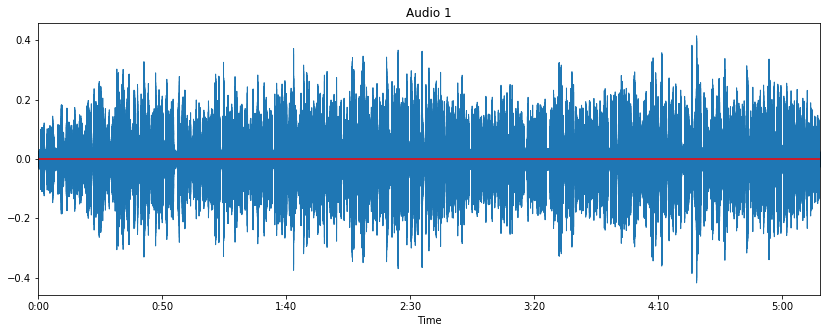

```python
# Leitura do audio
audio_series, sample_rate = librosa.load('Audio 1_Analise.mp3')

plt.figure(figsize=(14, 5))
librosa.display.waveplot(audio_series, sr=sample_rate)

# Desenha Linha no Eixo Y de Frequencia
plt.axhline(0, color='red')

# Titulo do Grafico
plt.title('Audio 1')
```

```python
# Audio 1 - Primeira página do Texto
# Adiciona o Audio para execucao direto no Jupyter
#ipd.Audio('Audio 1_Analise.mp3')
```

### Audio 2

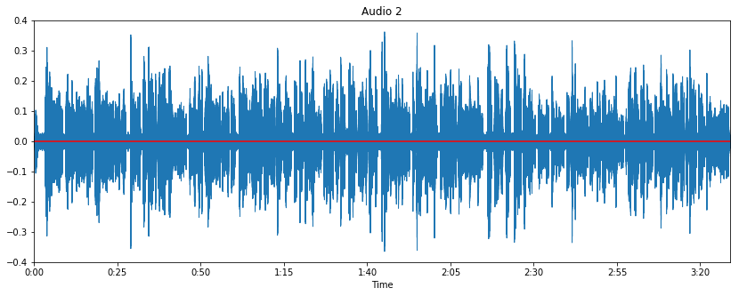

```python
# Leitura do audio
audio_series, sample_rate = librosa.load('Audio 2_Markdown.mp3')

plt.figure(figsize=(14, 5))
librosa.display.waveplot(audio_series, sr=sample_rate)

# Desenha Linha no Eixo Y de Frequencia
plt.axhline(0, color='red')

# Titulo do Grafico
plt.title('Audio 2')
```

```python
# Audio 2 - Segunda página do texto
# Adiciona o Audio para execucao direto no Jupyter
#ipd.Audio('Audio 2_Markdown.mp3')
```

- **Perda de áudio** devido a compactação durante a gravação ou pós conversão;
- **Pausa do áudio** majoritário (como falas, músicas ou qualquer outro tipo de áudio que presenta de forma geral o arquivo em análise);

A não existência de conteúdo na frequência zero comprova que o arquivo possui certo nível de ruído, mesmo que seja pouco. Isto é, o áudio foi gravado em local que apresenta ruídos externos, que podem ser:

- **Indiretos**: Ruídos que não afetam o conteúdo principal do áudio, como barulhos de ambiente;
- **Diretos**: Ruídos que afetam o conteúdo principal do áudio, como outras pessoas conversando próximo ao microfone ;

Estes ruídos podem afetar a transcrição realizada através de um algorítmo de *Speech to Text*, que identifica o áudio e transcreve para conteúdo textual. Essa técnica será utilizada ao decorrer desta análise.

# Conversão de Áudio para Texto - Speech to Text

## Audio 1

Audio original:  
Audio 1_Orig.m4a;

Audio utilizado para análise:  
Audio 1_Analise.mp3;

Informações sobre o Áudio Original:

[figure not shown]

Motivo:  
Watson Speech to Text Demo não suporta formato iTunes .m4a.

Conversão:  
MP3 320kbps, Bitrate constante, 44khz 2 canais;  
https://online-audio-converter.com/pt/

Speech to Text:  
IBM Watson, Speech to Text Demo, Brazilian Portoguese narrowband model (8Khz)  
https://speech-to-text-demo.ng.bluemix.net/

```python
# Texto original
texto_1 = open('Transcrição 1 - Original.txt', 'r').read().replace("\n", "")

# Speech to Text
# Utilizado Audio convertido, Audio 1.mp3
s2t_1 = open('Transcrição 1 - Speech to Text.txt', 'r').read().replace("\n", "")
```

### Texto Original

```python
texto_1
```

```
'O idoso não é um ser de outro planeta. É um consumidor normal, com hábitos normais, que interage nas redes sociais, usa tablet, computadores e smartphones. Eu piloto drones!”, assegura o publicitário Roberto Duailibi, o “D” da agência DPZ&T, que aos oitenta e três anos de idade continua trabalhando…
```

### Speech to Text

```python
s2t_1
```

```
'O idoso não é um ser do planeta. Incumbe ao consumidor normal com habilidades normais. Uma opção mais quem terá ivana geco sociais. Musa table computadores e smartphones. E o piloto drones asseguro publicitário ou perto do rali de. Voltei da agência de pis de itens. Que aos oitenta e três anos de i…
```

## Audio 2

Audio original:  
Parte 1: Audio 2_Orig.opus;

Audio utilizado para análise:  
Parte 1: Audio 2_Orig.opus;

Informações sobre o Áudio Original:

[figure not shown]

Motivo:  
Watson Speech to Text Demo suporta formato .opus.

Conversão:  
Não foi necessário;

Speech to Text:  
IBM Watson, Speech to Text Demo, Brazilian Portoguese narrowband model (8Khz)  
https://speech-to-text-demo.ng.bluemix.net/

```python
# Texto original
texto_2 = open('Transcrição 2 - Original.txt', 'r').read().replace("\n", "")

# Speech to Text
s2t_2 = open('Transcrição 2 - Speech to Text.txt', 'r').read().replace("\n", "")
```

### Original

```python
texto_2
```

```
'A Revolução da longevidade está transformando profundamente os mercados de atuação das empresas. Indústria, varejo e serviços voltados ao consumidor precisam definir e implementar estratégias específicas voltadas ao público sênior que, apesar de compor a faixa demográfica de maior crescimento e pod…
```

### Speech to Text

```python
s2t_2
```

```
'Com a revolução da longevidade está transformando profundamente os mercados de atuação das empresas. Indústria varejo serviços voltar ao consumidor precisam definir e implementar estratégias para. Mas vou reabre ao público se o. Que apesar de compor a faixa demográfica da maior do maior crescimento…
```

# Avaliação

A Avaliação se dá através da comparação entre o texto original e o texto transcrito pelo algoritmo de Speech to Text.  
A comparação não é feita somente calculando o erro. Para determinar a qualidade (ou a porcentagem de erro) consideramos outros pontos, que são:

- Palavras substituidas (S);
- Palavras excluidas (D);
- Palavras adicionadas (I);

O cálculo é conhecido como *WER*, ou *Word Error Rate*, e é feito através da seguinte fórmula:

$$WER = 100 * \frac{S + D + I}{|W|}$$

A Biblioteca **jiwer**, para linguagem Python, realiza o cálculo do *WER*.

Por padrão, a biblioteca realiza alguns pré-processamento que auxiliam para uma medição de erro mais acurada. Os pré-processamentos padrão são:

- Remoção de espaços em branco;
- Remoção de pontos e virgulas;
- Palavras são colocadas em caixa-baixa;
- Palavras são tokenizadas, ou seja, são separadas individualmente;

```python
# Import
from jiwer import wer
```

### Áudio 1

```python
erro_1 = wer(texto_1, s2t_1)

print('A taxa de error para o Audio 1 é de {0:.2f}%'.format(erro_1*100))
```

```
A taxa de error para o Audio 1 é de 33.56%
```

### Áudio 2

```python
erro_2 = wer(texto_2, s2t_2)

print('A taxa de error para o Audio 2 é de {0:.2f}%'.format(erro_2*100))
```

```
A taxa de error para o Audio 2 é de 28.40%
```

# Conclusão

Através de áudios gravados por aparelhos eletrônicos, como smartphones, computadores e até mesmo aparelhos profissionais para captura de áudio, é possível aplicar técnicas de Text Mining e Speech Analytics para uma melhor compreensão em grandes volumes de gravações.

A Qualidade de gravação é o divisor de aguás quando se trata de Speech Analytics. Quanto mais qualidade no áudio, melhor qualidade terá sua análise.

Vale ressaltar que o primeiro áudio possuia uma melhor qualidade, mas durante a avaliação foi o que mais apresentou erros. Ao ouvir o áudio por completo é possível identificar a presença de mais de uma pessoa falando. O Segundo áudio, apesar de uma qualidade mais baixa e com mais ruídos diretos, apresentou uma taxa de erro menor.

Este trabalho busca mostrar como a qualidade do áudio afeta o resultado da transcrição. Em nossos áudios, que apresentam compressão, tivemos valores relativamente altos de erro, o que afeta diretamente a qualidade de uma análise. É importante ressaltar que a taxa de erro não é decisória para a continuação de um projeto voltado para Speech Analytics. Quando tratamos de situações exatas, a taxa de erro sempre existirá, e a decisão final de um projeto que utiliza este tipo de técnologia deve-se ao ponto de equilíbrio entre a perda e o ganho que este resultado entrega.

Para download do link completo, contendo os áudio, clique aqui